# Assignment-03

Wenjia and Anna

2023-05-10

# Task 1

# New functions in Chapter 2.5 - 2.7 of MSMB Huber:

read fasta file: library(“Biostrings”) staph = readDNAStringSet(“../data/staphsequence.ffn.txt”, “fasta”)

look at the x’s object: staph[x]

get the frequencies of bases: letterFrequency(staph[[1]], letters = “ACGT”, OR = 0)

get a matrix of bases frequency: letterFrq = vapply(staph, letterFrequency, FUN.VALUE = numeric(4), letters = “ACGT”, OR = 0) tab10= letterFrq[, 1:10] computeProportions = function(x) {x/sum(x)} prop10 = apply(tab10, 2, computeProportions) round(prop10, digits = 2)

sum of a column: cs = colSums(tab10)

intermezzo quantile: quantile(simulstat, qs)

QQ_plots: qqplot(qchisq(ppoints(B), df = 30), simulstat, main =““, xlab = expression(chi[nu==30]^2), asp = 1, cex = 0.5, pch = 16) abline(a = 0, b = 1, col =”red”) –> faster and does not need the 1000 simulations

Chargaff’s Rule: -> tetranucleotide hypothesis: wether the nucleotides occured at equal frequencies.

load(“../dat/ChargaffTable.RData”) ChargaffTable

Two categorical variables: -> contingency table

-> checking a relationship in a model : chisq.test()

Hardy-Weinberg equilibrium library(“HardyWeinberg”) data(“mourant”) Mourant[214:216,] -> a table as the output

maximum likelihood: (in Hardy-Weinberg equilibrium, using the HW-package) af(c(nMM, nMN, nNN))

Visual comparison to the Hardy-Weinberg equilibrium:

pops = c(1, 69, 128, 148, 192) genotypeFrequencies = as.matrix(Mourant[, c(“MM”, “MN”, “NN”)]) HWTernaryPlot(genotypeFrequencies[pops, ], markerlab = Mourant$Country[pops], alpha = 0.0001, curvecols = c(“red”, rep(“purple”, 4)), mcex = 0.75, vertex.cex = 1)

Kozak Motif: –> sequence occurring close to start codon, but not equally likely

library(“seqLogo”) load(“../data/kozak.RDAta”) kozak –> a table as output

for graphical visualization: sequence logo

pwm = makePWM(kozak) seqLogo(pwn, ic.scale = FALSE)

#

# Task 2

# All plotting types in R:

1, Histogram:

hist(data, main = “topic”, xlab = “xais”, ylab = “yaix”, (col = color, border = bordercolor))

suitable for continuous data types visualize the distribution of a continuous variable

2, density plot

density(data, (main = ““, xlab =”“, col = color1))

suitable for continuous data types visualize the distribution of a variable by displaying its density

3, line plot

plot(a, b, type = “l”)

suitable for continuous data types visualize the trend of a continuous variable over time or some other variable

4, scatter plot

plot(a, b)

suitable for continuous data types visualize the relationship between two variables

5, box plot

boxplot(value1 ~ value2 ( vector/formula ), data, notch, varwidth, names, main)

suitable for continuous data types visualize the distribution of a continuous variable by displaying the quartiles

6, bar plot

barplot(y, names.arg = x)

suitable for categorical data types compare the values

7, heatmaps

heatmap(data, scale = “none”)

use custom color set: col<- colorRampPalette(c(“red”, “white”, “blue”))(256)

suitable for categorical data types visualize the relationship between two variables

8, pie charts:

pie(vector, labels, radius, main, col, clockwise)

suitable for categorical data types display the proportion of each category in a categorical variable

# how to choose xlab, ylab, title and configure textsize, margin size and number of plots displayed:

using following commands:

xlab = “lables_of_values” ylab = “lables_of_values” main = “title”

text size: cex = 1.5 margin size: par(mar = c(5, 4, 4, 2) + 0.1)) display two plots side by side: par(mfrow = c(1,2))

# what are the types of data:

Qualitative Data Type: Nominal Ordinal

Quantitative Data Type: Discrete Continuous

Continuous - numeric data can have any value within a range. Examples include time, height and temperature.

Discrete - numeric data that canonly have certain values. Examples include shoe size, number of people in a room and the number of marks on a test.

Categoric - the data arewords. Examples include colour such as ‘red’ or ‘blue’, and how an object feels like, eg: ‘rough’ or ‘smooth’.

sources: https://www.bbc.co.uk/bitesize/topics/zsg6m39/articles/zxkh6g8

# Recap 1: Gene expression

–> understanding impact of log transformation

```r
# mean of each gene without log transformation
meanX25_0_r1 <- mean(survey$X25_0_r1)
meanX25_0_r2 <- mean(survey$X25_0_r2)
meanX25_0_r3 <- mean(survey$X25_0_r3)
meanX42_10_r1 <- mean(survey$X42_10_r1)
meanX42_10_r2 <- mean(survey$X42_10_r2)
meanX42_10_r3 <- mean(survey$X42_10_r3)
meanX42_30_r1 <- mean(survey$X42_30_r1)
meanX42_30_r2 <- mean(survey$X42_30_r2)
meanX42_30_r3 <- mean(survey$X42_30_r3)

cat("mean 0_r1 :", meanX25_0_r1)
```

```
## mean 0_r1 : 803.3108
```

```r
cat("mean 0_r2: " ,meanX25_0_r2)
```

```
## mean 0_r2:  743.1636
```

```r
cat("mean 0_r3 : " ,meanX25_0_r3)
```

```
## mean 0_r3 :  1124.993
```

```r
cat("mean 10_r1: ", meanX42_10_r1)
```

```
## mean 10_r1:  902.9632
```

```r
cat("mean 10_r2: ", meanX42_10_r2)
```

```
## mean 10_r2:  550.1887
```

```r
cat("mean 10_r3: ", meanX42_10_r3)
```

```
## mean 10_r3:  821.47
```

```r
cat("mean 30_r1: ", meanX42_30_r1)
```

```
## mean 30_r1:  788.0901
```

```r
cat("mean 30_r2: ", meanX42_30_r2)
```

```
## mean 30_r2:  903.8491
```

```r
cat("mean 30_r3: ", meanX42_30_r3)
```

```
## mean 30_r3:  800.865
```

```r
#mean with log
log_meanX25_0_r1 <- log(mean(survey$X25_0_r1))
log_meanX25_0_r2 <- log(mean(survey$X25_0_r2))
log_meanX25_0_r3 <- log(mean(survey$X25_0_r3))
log_meanX42_10_r1 <- log(mean(survey$X42_10_r1))
log_meanX42_10_r2 <- log(mean(survey$X42_10_r2))
log_meanX42_10_r3 <- log(mean(survey$X42_10_r3))
log_meanX42_30_r1 <- log(mean(survey$X42_30_r1))
log_meanX42_30_r2 <- log(mean(survey$X42_30_r2))
log_meanX42_30_r3 <- log(mean(survey$X42_30_r3))

cat("log_mean 0_r1 :", log_meanX25_0_r1)
```

```
## log_mean 0_r1 : 6.688742
```

```r
cat("log_mean 0_r2: " ,log_meanX25_0_r2)
```

```
## log_mean 0_r2:  6.610916
```

```r
cat("log_mean 0_r3 : " ,log_meanX25_0_r3)
```

```
## log_mean 0_r3 :  7.025532
```

```r
cat("log_mean 10_r1: ", log_meanX42_10_r1)
```

```
## log_mean 10_r1:  6.805682
```

```r
cat("log_mean 10_r2: ", log_meanX42_10_r2)
```

```
## log_mean 10_r2:  6.310261
```

```r
cat("log_mean 10_r3: ", log_meanX42_10_r3)
```

```
## log_mean 10_r3:  6.711095
```

```r
cat("log_mean 30_r1: ", log_meanX42_30_r1)
```

```
## log_mean 30_r1:  6.669612
```

```r
cat("log_mean 30_r2: ", log_meanX42_30_r2)
```

```
## log_mean 30_r2:  6.806662
```

```r
cat("log_mean 30_r3: ", log_meanX42_30_r3)
```

```
## log_mean 30_r3:  6.685692
```

```r
#Standard deviation without log transformation
sd_X25_0_r1 <- sd(survey$X25_0_r1)
sd_X25_0_r2 <- sd(survey$X25_0_r2)
sd_X25_0_r3 <- sd(survey$X25_0_r3)
sd_X42_10_r1 <- sd(survey$X42_10_r1)
sd_X42_10_r2 <- sd(survey$X42_10_r2)
sd_X42_10_r3 <- sd(survey$X42_10_r3)
sd_X42_30_r1 <- sd(survey$X42_30_r1)
sd_X42_30_r2 <- sd(survey$X42_30_r2)
sd_X42_30_r3 <- sd(survey$X42_30_r3)

cat("sd 0_r1 :", sd_X25_0_r1)
```

```
## sd 0_r1 : 4209.143
```

```r
cat("sd 0_r2: " ,sd_X25_0_r2)
```

```
## sd 0_r2:  3974.807
```

```r
cat("sd 0_r3 : " ,sd_X25_0_r3)
```

```
## sd 0_r3 :  4621.672
```

```r
cat("sd 10_r1: ", sd_X42_10_r1)
```

```
## sd 10_r1:  4423.508
```

```r
cat("sd 10_r2: ", sd_X42_10_r2)
```

```
## sd 10_r2:  2769.641
```

```r
cat("sd 10_r3: ", sd_X42_10_r3)
```

```
## sd 10_r3:  4381.546
```

```r
cat("sd 30_r1: ", sd_X42_30_r1)
```

```
## sd 30_r1:  5487.325
```

```r
cat("sd 30_r2: ", sd_X42_30_r2)
```

```
## sd 30_r2:  5981.755
```

```r
cat("sd 30_r3: ", sd_X42_30_r3)
```

```
## sd 30_r3:  5378.69
```

```r
#SD with log transformation

log_sd_X25_0_r1 <- log(sd(survey$X25_0_r1))
log_sd_X25_0_r2 <- log(sd(survey$X25_0_r2))
log_sd_X25_0_r3 <- log(sd(survey$X25_0_r3))
log_sd_X42_10_r1 <-log(sd(survey$X42_10_r1))
log_sd_X42_10_r2 <- log(sd(survey$X42_10_r2))
log_sd_X42_10_r3 <- log(sd(survey$X42_10_r3))
log_sd_X42_30_r1 <- log(sd(survey$X42_30_r1))
log_sd_X42_30_r2 <- log(sd(survey$X42_30_r2))
log_sd_X42_30_r3 <- log(sd(survey$X42_30_r3))

cat("log_sd 0_r1 :", log_sd_X25_0_r1)
```

```
## log_sd 0_r1 : 8.345014
```

```r
cat("log_sd 0_r2: " ,log_sd_X25_0_r2)
```

```
## log_sd 0_r2:  8.287732
```

```r
cat("log_sd 0_r3 : " ,log_sd_X25_0_r3)
```

```
## log_sd 0_r3 :  8.438512
```

```r
cat("log_sd 10_r1: ", log_sd_X42_10_r1)
```

```
## log_sd 10_r1:  8.394688
```

```r
cat("log_sd 10_r2: ", log_sd_X42_10_r2)
```

```
## log_sd 10_r2:  7.926473
```

```r
cat("log_sd 10_r3: ", log_sd_X42_10_r3)
```

```
## log_sd 10_r3:  8.385157
```

```r
cat("log_sd 30_r1: ", log_sd_X42_30_r1)
```

```
## log_sd 30_r1:  8.610196
```

```r
cat("log_sd 30_r2: ", log_sd_X42_30_r2)
```

```
## log_sd 30_r2:  8.696469
```

```r
cat("log_sd 30_r3: ", log_sd_X42_30_r3)
```

```
## log_sd 30_r3:  8.5902
```

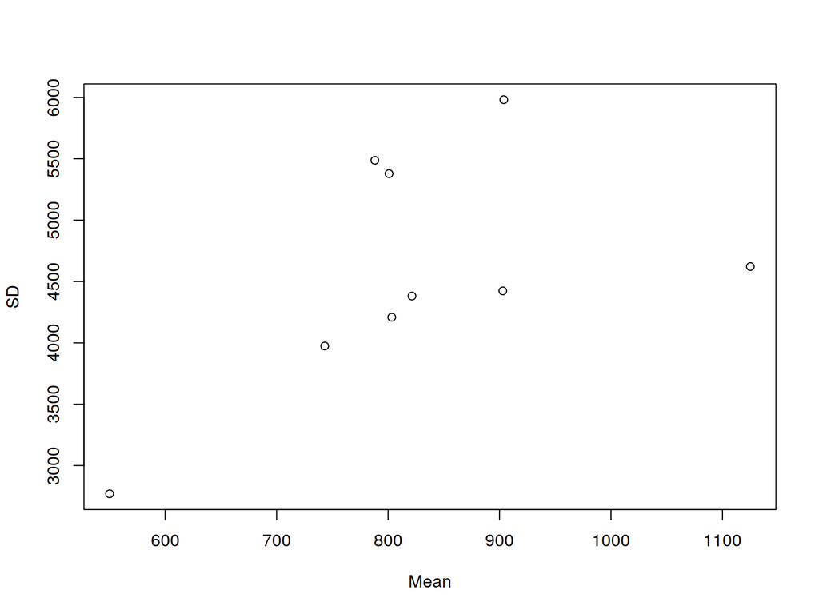

```r
#Zusammenfassen
means<- c(meanX25_0_r1, meanX25_0_r2, meanX25_0_r3, meanX42_10_r1, meanX42_10_r2, meanX42_10_r3, meanX42_30_r1, meanX42_30_r2, meanX42_30_r3)
sds<- c(sd_X25_0_r1, sd_X25_0_r2, sd_X25_0_r3, sd_X42_10_r1, sd_X42_10_r2, sd_X42_10_r3, sd_X42_30_r1, sd_X42_30_r2, sd_X42_30_r3)

#Create Scatter plot without log transformation
plot(means, sds, xlab= "Mean", ylab="SD")
```

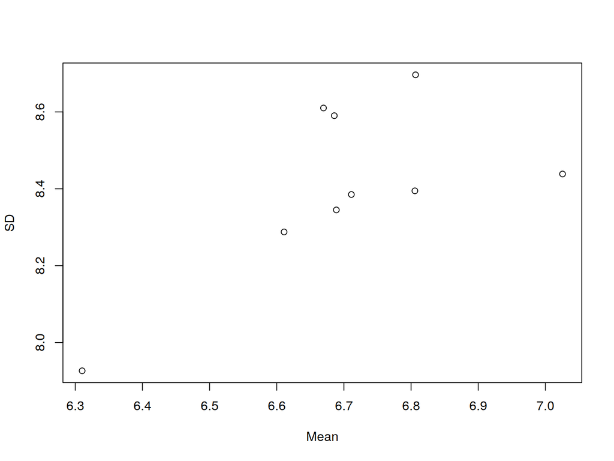

```r
#Zusammenfassend mit Logarithmus
means_log <- c(log_meanX25_0_r1, log_meanX25_0_r2, log_meanX25_0_r3, log_meanX42_10_r1, log_meanX42_10_r2, log_meanX42_10_r3, log_meanX42_30_r1, log_meanX42_30_r2, log_meanX42_30_r3)
sds_log <- c(log_sd_X25_0_r1, log_sd_X25_0_r2, log_sd_X25_0_r3, log_sd_X42_10_r1, log_sd_X42_10_r2, log_sd_X42_10_r3, log_sd_X42_30_r1, log_sd_X42_30_r2, log_sd_X42_30_r3)

#Create Scatter plot with log transformation
plot(means_log, sds_log, xlab="Mean", ylab="SD")
```

```r
YF_data<- survey[survey$gene_id=="YFL014W",]

show(YF_data)
```

```
##      gene_id X25_0_r1 X25_0_r2 X25_0_r3 X42_10_r1 X42_10_r2 X42_10_r3 X42_30_r1
## 2411 YFL014W        9       86      455      1373      1723      2940      6107
##      X42_30_r2 X42_30_r3
## 2411     13126      9212
```

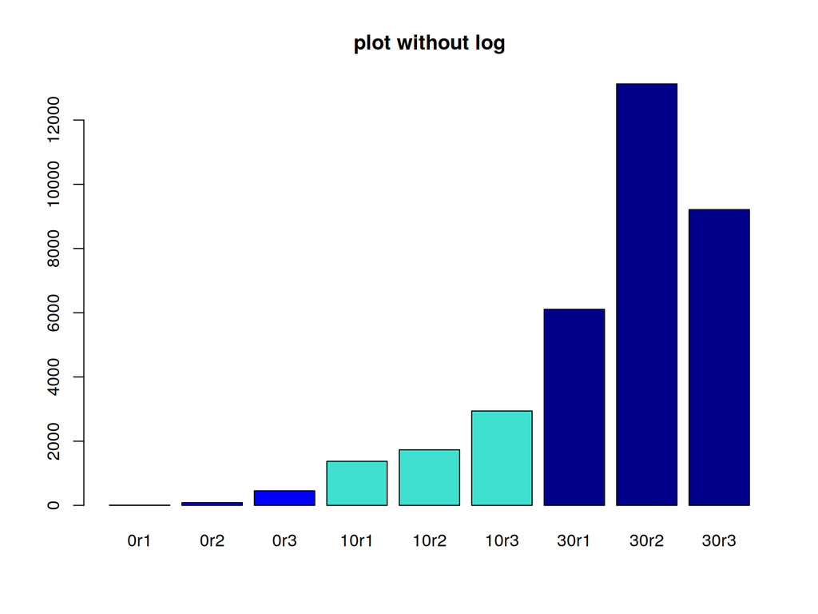

```r
x<- c("0r1", "0r2", "0r3", "10r1", "10r2", "10r3", "30r1", "30r2", "30r3")
y<- c(9, 86, 455, 1373, 1732, 2940, 6107, 13126, 9212)
mycolors <- c("blue", "blue", "blue","turquoise",  "turquoise", "turquoise", "blue4", "blue4", "blue4")


barplot(y, names.arg= x,
        args.legend = list(x = "topleft", bty="n"), col=mycolors, main="plot without log")
```

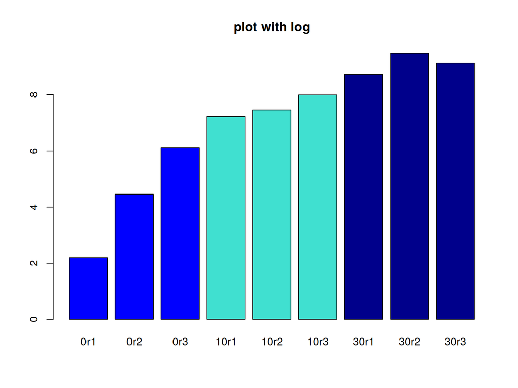

```r
barplot(log(y), names.arg= x,
        args.legend = list(x = "topleft", bty="n"), col=mycolors, main="plot with log")
```

# YFLO14W as line plot

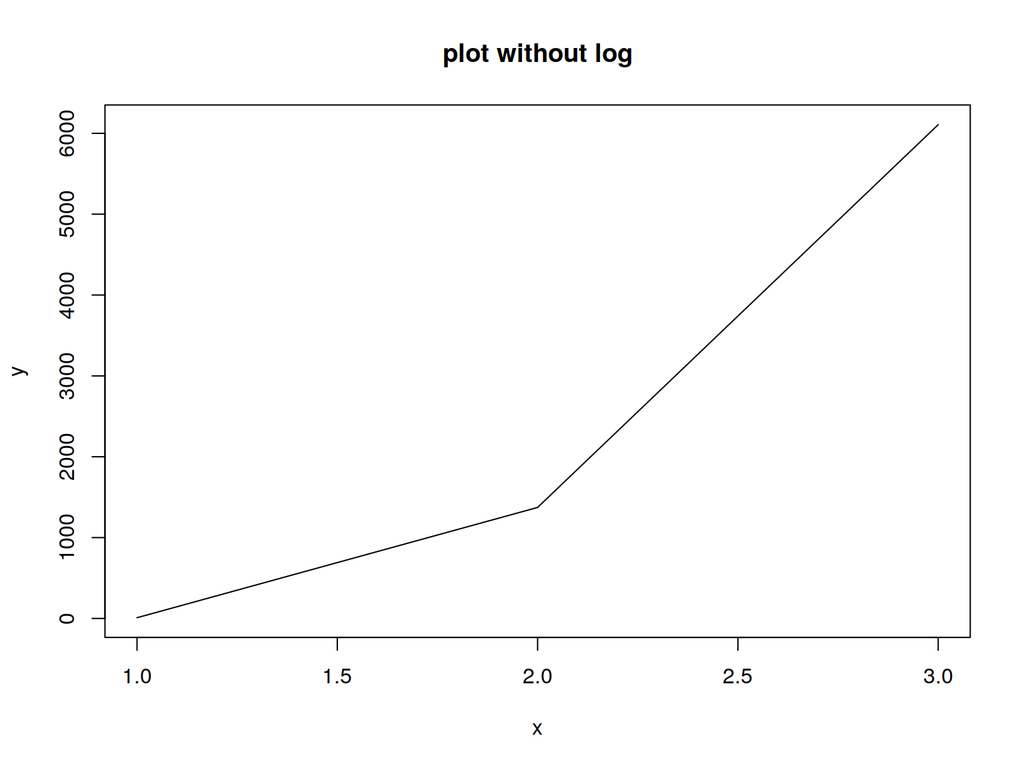

```r
x<- c(1,2,3)
y<- c(mean(9, 86, 455), mean(1373, 1732, 2940), mean(6107, 13126, 9212))
Llabels <- c("25", "42_10", "42_30")

plot(x, y, type="l", main="plot without log")
```

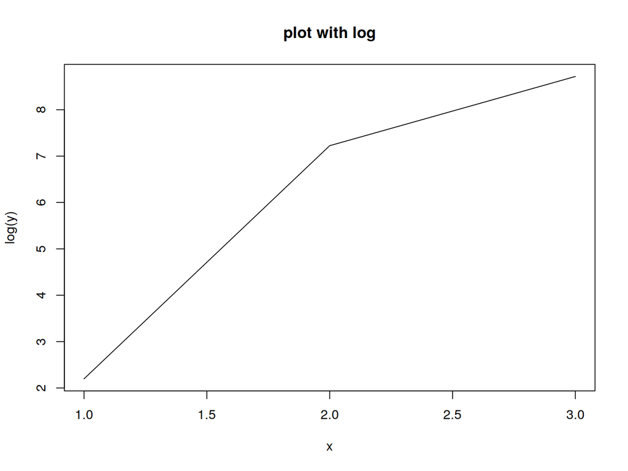

```r
plot(x, log(y), type="l", main="plot with log")
```

##mean per gene per condition

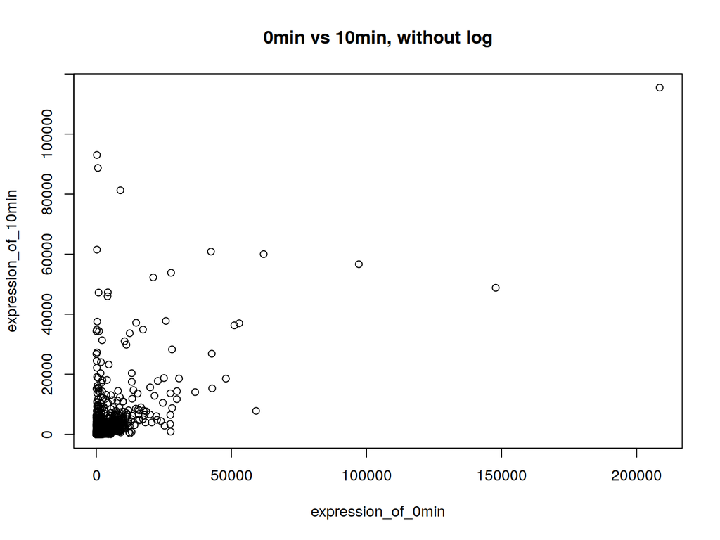

```r
mean_25 <- (survey$X25_0_r1 + survey$X25_0_r2 + survey$X25_0_r3)/3
mean_42_10 <- (survey$X42_10_r1 + survey$X42_10_r2 + survey$X42_10_r3)/3
mean_42_30 <- (survey$X42_30_r1 + survey$X42_30_r2 + survey$X42_30_r3)/3
df_mean <- data.frame(gene_id=survey$gene_id,
                 X25_0=mean_25,
                 X42_10=mean_42_10,
                 X42_30=mean_42_30)
expression_of_0min <- df_mean$X25_0
expression_of_10min <- df_mean$X42_10
expression_of_30min <- df_mean$X42_30
plot( expression_of_0min, expression_of_10min  ,  main="0min vs 10min, without log")
```

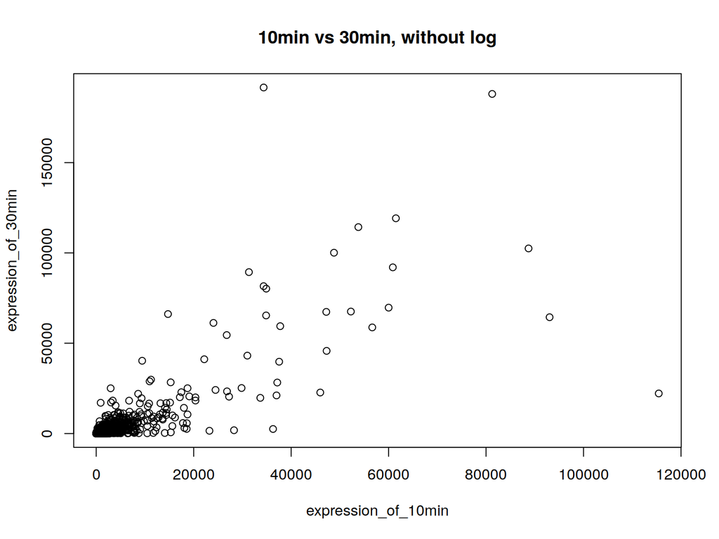

```r
plot( expression_of_10min, expression_of_30min  , main="10min vs 30min, without log")
```

```r
plot( log(expression_of_0min), log(expression_of_10min) , main="0min vs 10min, with log")
```

[output not shown]